# Homework 1

Author

Dana Kilbourne

Professional wrestling, while not everyone’s cup of tea, is big business. What started as a carnival act has turned into a global entertainment industry. Netflix recently started showing Monday Night Raw, a program from the biggest North American wrestling company, WWE – this deal is reportedly worth $5 billion. Like any large entity, WWE is not without competition, drama, and scandal.

## General Tips

This is very much a step-by-step process. Don’t go crazy trying to get everything done with as few lines as possible. Read the documentation for the AlphaVantage api! Carefully explore the pages from cagematch. There isn’t a need to get too fancy with anything here – just go with simple function and all should be good. Don’t print comments, but use normal text for explanations.

## Step 1

In the `calls` folder, you’ll find 4 text files – these are transcripts from quarterly earnings calls. Read those files in (glob.glob will be very helpful here), with appropriate column names for ticker, quarter, and year columns; this should be done within a single function. Perform any data cleaning that you find necessary.

```python
import glob
import re
import pandas as pd


#create a function using regex that will use the files we got
def load_transcripts():
    files = glob.glob(r"C:/Users/kilbo/Documents/Spring 2025/Unstructured Data Analytics/assignment_1/calls/*")
    data = []

    for file in files:
        match = re.search(r'([a-z]+)_q(\d)_(\d{4})', file, re.IGNORECASE)
        if match:
            ticker = match.group(1).upper()
            quarter = f"Q{match.group(2)}"
            year = match.group(3)

            files_df = pd.read_table(file, header=None)
            files_df['ticker'] = ticker
            files_df['quarter'] = quarter
            files_df['year'] = year
            data.append(files_df)
        else:
            print(f"Skipping file {file} as it does not match the expected pattern.")
            continue
    df = pd.concat(data)
    return df

# Load the transcripts and print the first few rows
transcripts_df = load_transcripts()
print(transcripts_df.head())
```

```
                                  0 ticker quarter  year
0              Company Participants    EDR      Q3  2023
1                  James Marsh - IR    EDR      Q3  2023
2                 Ari Emanuel - CEO    EDR      Q3  2023
3                Jason Lublin - CFO    EDR      Q3  2023
4  Mark Shapiro - President and COO    EDR      Q3  2023
```

## Step 2

Use the AlphaVantage api to get daily stock prices for WWE and related tickers for the last 5 years – pay attention to your data. You cannot use any AlphaVantage packages (i.e., you can only use requests to grab the data). Tell me about the general trend that you are seeing. I don’t care which viz package you use, but plotly is solid and plotnine is good for ggplot2 users.

```python
import requests
#alpha vantage key
av_k = "0CtBRPX7XVVxYRapC2eGP6mZ4Z6ZkXWuZCfgJt1E"

av_symbol = ['WWE', 'TKO', 'DIS', 'FOX', 'CMCSA']

stock = []

for symbols in av_symbol:
  url = f'https://www.alphavantage.co/query?function=TIME_SERIES_DAILY&symbol={symbols}&apikey={av_k}&outputsize=full'
  av_request = requests.get(url)

  av_json = av_request.json()

  series_data = av_json.get('Time Series (Daily)')

  meta_data = av_json['Meta Data']

  av_data = pd.DataFrame.from_dict(series_data, orient='index')

  av_data['symbol'] = meta_data['2. Symbol']

  av_data.reset_index(inplace = True)

  av_data = av_data.rename(columns = {'index':'date'})

  stock.append(av_data)

complete_stocks = pd.concat(stock)

print(complete_stocks.head())
```

```
         date   1. open   2. high   3. low  4. close 5. volume symbol
0  2023-09-11   99.5100  101.9400  98.0700  100.6500   1642135    WWE
1  2023-09-08  101.0400  101.3500  97.0700   98.0500   1327552    WWE
2  2023-09-07   99.2900  101.4100  98.5500   99.4100   1043837    WWE
3  2023-09-06  100.7000  100.8000  98.0400  100.0000   1164664    WWE
4  2023-09-05  103.0000  103.0000  96.1150  100.0700   1692387    WWE
```

```python
import pandas as pd
#Filter only the most recent five years from today's date
complete_stocks['date'] = pd.to_datetime(complete_stocks['date'])
complete_stocks = complete_stocks.sort_values(by='date', ascending=False)


from datetime import date

#Get the date today
most_recent_date = date.today()

#Calculate the cutoff date (5 years before the date today)
cutoff_date = most_recent_date - pd.DateOffset(years=5)

#Create a new df and filter the dataframe
stocks_last_5_years = complete_stocks[complete_stocks['date'] >= cutoff_date]

#str(stocks_last_5_years)
print(stocks_last_5_years.dtypes)

#create a new column to use later in the graph
stocks_last_5_years['close'] = pd.to_numeric(stocks_last_5_years['4. close'])
stocks_last_5_years['open'] = pd.to_numeric(stocks_last_5_years['1. open'])
```

```
date         datetime64[ns]
1. open              object
2. high              object
3. low               object
4. close             object
5. volume            object
symbol               object
dtype: object
```

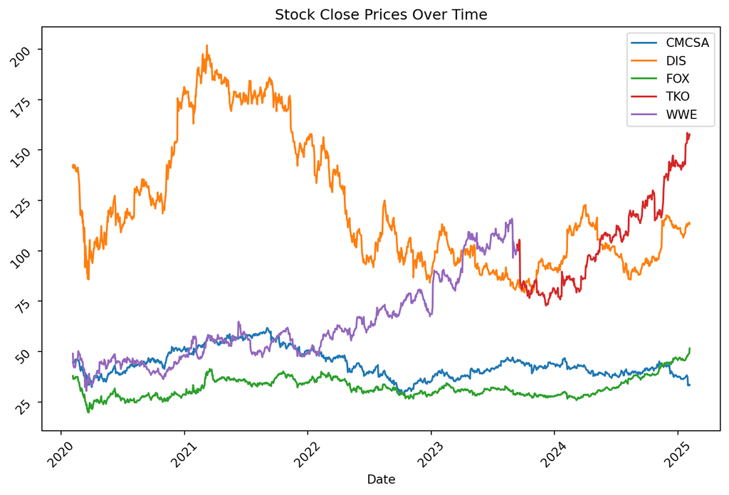

```python
#this was opening in a browser so i

# import plotly.express as px
#
# #creating a line plot of the stocks over the last 5 years
# figure = px.line(
#     stocks_last_5_years,
#     x='date',                # x-axis is the date
#     y='4. close',            # y-axis is the closing price
#     color='symbol',          # Color lines based on the stock symbol
#     title='Line Chart of Closing Stock Price by Time',  # Title of the chart
#     labels={"4. close": "Closing Price", "date": "Date"}  # Axis labels
# )
#
#
# figure.show()


import matplotlib.pyplot as plt

plt.figure(figsize=(10, 6))

# Group by 'symbol' and plot each one
for symbol, group in stocks_last_5_years.groupby('symbol'):
    plt.plot(group['date'], group['close'], label=symbol)

# Adding labels and title
plt.xlabel('Date')
#plt.ylabel('Close Price')
plt.title('Stock Close Prices Over Time')

plt.legend()

# Rotate labels
plt.xticks(rotation=45)
plt.yticks(rotation=45)


# display the plot
plt.show()
```

## Step 3

Just like every other nerdy hobby, professional wrestling draws dedicated fans. Wrestling fans often go to cagematch.net to leave reviews for matches, shows, and wrestlers. The following link contains the top 100 matches on cagematch: https://www.cagematch.net/?id=111&view=statistics

```python
import requests
from bs4 import BeautifulSoup
import pandas as pd

#use beautiful soup and then iterate over to find all values in the table


# URL of the page containing the table
url = "https://www.cagematch.net/?id=111&view=statistics"

# Send a  request to the webpage
response = requests.get(url)

# see if the request went through
if response.status_code == 200:
    # Parse the HTML content
    soup = BeautifulSoup(response.content, 'html.parser')

    # Locate the div with class "Table"
    table_div = soup.find("div", {"class": "Table"})

    if table_div:
        # locate all rows within the table
        rows = table_div.find_all("tr")[1:]  # Skip the header row

        # extract data from each row
        data = []
        for row in rows:
            columns = row.find_all("td")
            data.append({
                "Rank": columns[0].text.strip(),
                "Date": columns[1].text.strip(),
                "Promotion": columns[2].img["alt"].strip() if columns[2].img else None,
                "Match": columns[3].text.strip(),
                "WON Rating": columns[4].text.strip(),
                "Match Type": columns[5].text.strip(),
                "Rating": columns[6].text.strip(),
                "Votes": columns[7].text.strip()
            })

        df = pd.DataFrame(data)

      #  print(df)
```

- What is the correlation between WON ratings and cagematch ratings?

```python
import re

def convert_won_rating(rating):
  if not isinstance(rating, str):
    return None
  match = re.search(r'(\d+/\d+)$', rating) # literal asterisk, between 1 and 5, capturing group, non greedy quantifier, literal #asterisk, escape, star, escape, other slash, escape, digit, or digit, other slash, digit, non greedy quantifier
  if match:
    return match.group(1)
  else:
    return None

df["WON Rating Numeric"] = df["WON Rating"].apply(convert_won_rating)

#print(df)


# Convert the ratings to numeric, forcing errors to NaN

df['Won_Rating_Clean'] = pd.to_numeric(df['WON Rating Numeric'], errors='coerce').astype('Int64')

# map the dictionary for fractions
fraction_map = {'1/4': 0.25, '1/2': 0.5, '3/4': 0.75}

# apply the mapping to the column
df['Won_Rating_Clean'] = df['WON Rating Numeric'].map(fraction_map)

#print(df)
#print(df.dtypes)

#now do the correlation between won ratings and cagematch ratings

# Calculate the correlation between WON rating and Cagematch rating
correlation = df['Won_Rating_Clean'].corr(df['Rating'])

print(f"The correlation between WON ratings and Cagematch ratings is: {correlation}")
```

```
The correlation between WON ratings and Cagematch ratings is: -0.3247343706934598
```

** Which wrestler has the most matches in the top 100?

```python
from collections import Counter

#create empty
all_wrestlers = []

#iterate over every match to split the column match and end up with the wrestlers names
for match in df["Match"]:
  two = match.split(" vs. ") if " vs. " in match else [match]

  for side in two:
    wrestlers = side.split(" & ")
    all_wrestlers.extend(wrestlers)


#print(all_wrestlers)

count_wrestlers = Counter(all_wrestlers)
most_wrestler = count_wrestlers.most_common(1)[0]
```

Kenny Omega has the most matches in the top 100 with 15 matches.

*** Which promotion has the most matches in the top 100?

```python
# group by the promotion & count the number
count_promotion = df["Promotion"].value_counts()


print(count_promotion)
```

```
Promotion
New Japan Pro Wrestling                 35
World Wrestling Entertainment           14
All Japan Pro Wrestling                 12
All Elite Wrestling                     12
Ring Of Honor                            8
Pro Wrestling NOAH                       6
All Japan Women's Pro-Wrestling          4
World Wonder Ring Stardom                2
Total Nonstop Action Wrestling           1
DDT Pro Wrestling                        1
GAEA Japan                               1
Lucha Underground                        1
Japanese Women Pro-Wrestling Project     1
World Championship Wrestling             1
JTO                                      1
Name: count, dtype: int64
```

**** What is each promotion’s average WON rating?

```python
# group by the category and do it by average
grouped = df.groupby('Promotion')['Won_Rating_Clean'].mean()

print(grouped)
```

```
Promotion
All Elite Wrestling                     0.535714
All Japan Pro Wrestling                 0.750000
All Japan Women's Pro-Wrestling         0.750000
DDT Pro Wrestling                            NaN
GAEA Japan                                   NaN
JTO                                     0.750000
Japanese Women Pro-Wrestling Project         NaN
Lucha Underground                            NaN
New Japan Pro Wrestling                 0.573529
Pro Wrestling NOAH                      0.687500
Ring Of Honor                           0.625000
Total Nonstop Action Wrestling               NaN
World Championship Wrestling                 NaN
World Wonder Ring Stardom               0.500000
World Wrestling Entertainment           0.611111
Name: Won_Rating_Clean, dtype: float64
```

***** Select any single match and get the comments and ratings for that match into a data frame.

```python
#use beautiful soup again to find all the comments of a single match

url = "https://www.cagematch.net/?id=111&nr=8034&page=99"
response = requests.get(url)

soup = BeautifulSoup(response.content, "html.parser")

comments_section = soup.find_all("div", class_="Comment")

comments_data = []

#iterate over the comments to make sure you are getting each comment with the commenters name and rating of the match
for comment in comments_section:
    commenter = comment.find("a")  # <a> tag has the commenter's name
    comment_text = comment.find("div", class_="CommentContents")  # actual comment
    if commenter and comment_text:
        commenter_name = commenter.get_text(strip=True)
        comment_content = comment_text.get_text(strip=True)

        rating = comment.find("span", class_="Rating")
        if rating:
            rating_value = rating.get_text(strip=True)
        else:
            rating_value = "No rating"

        comments_data.append({
            "Commenter": commenter_name,
            "Rating": rating_value,
            "Comment": comment_content
        })

df_comments = pd.DataFrame(comments_data)

#print(df_comments)
```